# Solution to Hands-on exercise: Risk factor analysis

# Introduction

Data from an investigation of an outbreak of Salmonella in Funen County of Denmark in 1996. The data consisted of 39 cases od S. Typhimurium pahge type 12 and 73 controls matched for age, sex and municipality of residence. Data on numerous food exposures were recorded and a small subset of those data are included in the dataset sal.outbrk.

Reference: Molbak K, Hald D. An outbreak of Salmonella Typhimurium in the county of Funnen during the summer. A case-controlled study. Ugeskr Laeger. 1997; 159: 36.

- Import the data set sal.outbrk and format the variables

```r
salm <- read.csv("data/sal_outbrk.csv",
                header = TRUE, sep = ";")

salm[,4:17] <- as.data.frame(lapply(salm[,4:17], factor))
```

# glm: p-values and change of estimates

- fit a glm() model to the dataset make a summary, what is the AIC? which covariate are important for modelling?

```r
mod1 <- glm(formula = casecontrol ~ age + gender + eatbeef + eatpork + eatveal + eatlamb + eatpoul + eatcold + eatveg + eatfruit + eateggs + slt_a + dlr_a + dlr_b, family = binomial(link = logit),data = salm)

summary(mod1)
```

```
##
## Call:
## glm(formula = casecontrol ~ age + gender + eatbeef + eatpork +
##     eatveal + eatlamb + eatpoul + eatcold + eatveg + eatfruit +
##     eateggs + slt_a + dlr_a + dlr_b, family = binomial(link = logit),
##     data = salm)
##
## Deviance Residuals:
##      Min        1Q    Median        3Q       Max
## -2.10757  -0.50183  -0.17426  -0.00019   1.94506
##
## Coefficients:
##               Estimate Std. Error z value Pr(>|z|)
## (Intercept)  1.233e+01  3.956e+03   0.003   0.9975
## age          6.627e-03  2.592e-02   0.256   0.7982
## gender1      1.514e-01  8.690e-01   0.174   0.8617
## eatbeef1    -9.155e-01  9.235e-01  -0.991   0.3216
## eatpork1     1.169e+00  1.426e+00   0.820   0.4122
## eatveal1     3.863e+00  1.722e+00   2.244   0.0248 *
## eatlamb1    -1.200e+01  2.780e+03  -0.004   0.9966
## eatpoul1     2.632e+00  1.192e+00   2.208   0.0272 *
## eatcold1    -1.525e+01  3.956e+03  -0.004   0.9969
## eatveg1     -2.596e+00  4.332e+00  -0.599   0.5490
## eatfruit1   -2.489e+00  1.210e+00  -2.057   0.0397 *
## eateggs1     2.319e+00  1.320e+00   1.756   0.0791 .
## slt_a1       3.642e+00  1.442e+00   2.526   0.0115 *
## dlr_a1       2.321e-01  1.029e+00   0.226   0.8215
## dlr_b1      -4.901e-01  1.692e+00  -0.290   0.7721
## ---
## Signif. codes:  0 '***' 0.001 '**' 0.01 '*' 0.05 '.' 0.1 ' ' 1
##
## (Dispersion parameter for binomial family taken to be 1)
##
##     Null deviance: 81.547  on 72  degrees of freedom
## Residual deviance: 44.101  on 58  degrees of freedom
##   (39 observations deleted due to missingness)
## AIC: 74.101
##
## Number of Fisher Scoring iterations: 16
```

- restrict to complete case and re-fit. What changes do you observe?

```r
salm.cc <- salm[complete.cases(salm),]

mod2 <- glm(formula = casecontrol ~ age + gender + eatbeef + eatpork + eatveal + eatlamb + eatpoul + eatcold + eatveg + eatfruit + eateggs + slt_a + dlr_a + dlr_b, family = binomial(link = logit),data = salm.cc)

summary(mod2)
```

```
##
## Call:
## glm(formula = casecontrol ~ age + gender + eatbeef + eatpork +
##     eatveal + eatlamb + eatpoul + eatcold + eatveg + eatfruit +
##     eateggs + slt_a + dlr_a + dlr_b, family = binomial(link = logit),
##     data = salm.cc)
##
## Deviance Residuals:
##      Min        1Q    Median        3Q       Max
## -2.10757  -0.50183  -0.17426  -0.00019   1.94506
##
## Coefficients:
##               Estimate Std. Error z value Pr(>|z|)
## (Intercept)  1.233e+01  3.956e+03   0.003   0.9975
## age          6.627e-03  2.592e-02   0.256   0.7982
## gender1      1.514e-01  8.690e-01   0.174   0.8617
## eatbeef1    -9.155e-01  9.235e-01  -0.991   0.3216
## eatpork1     1.169e+00  1.426e+00   0.820   0.4122
## eatveal1     3.863e+00  1.722e+00   2.244   0.0248 *
## eatlamb1    -1.200e+01  2.780e+03  -0.004   0.9966
## eatpoul1     2.632e+00  1.192e+00   2.208   0.0272 *
## eatcold1    -1.525e+01  3.956e+03  -0.004   0.9969
## eatveg1     -2.596e+00  4.332e+00  -0.599   0.5490
## eatfruit1   -2.489e+00  1.210e+00  -2.057   0.0397 *
## eateggs1     2.319e+00  1.320e+00   1.756   0.0791 .
## slt_a1       3.642e+00  1.442e+00   2.526   0.0115 *
## dlr_a1       2.321e-01  1.029e+00   0.226   0.8215
## dlr_b1      -4.901e-01  1.692e+00  -0.290   0.7721
## ---
## Signif. codes:  0 '***' 0.001 '**' 0.01 '*' 0.05 '.' 0.1 ' ' 1
##
## (Dispersion parameter for binomial family taken to be 1)
##
##     Null deviance: 81.547  on 72  degrees of freedom
## Residual deviance: 44.101  on 58  degrees of freedom
## AIC: 74.101
##
## Number of Fisher Scoring iterations: 16
```

- Compute the change in estimates if the model is not adjusted for age and gender.

```r
mod3 <- glm(formula = casecontrol ~  eatbeef + eatpork + eatveal + eatlamb + eatpoul + eatcold + eatveg + eatfruit + eateggs + slt_a + dlr_a + dlr_b, family = binomial(link = logit),data = salm.cc)

mod2$coef
```

```
##   (Intercept)           age       gender1      eatbeef1      eatpork1
##  12.334827836   0.006627314   0.151428389  -0.915452910   1.169230506
##      eatveal1      eatlamb1      eatpoul1      eatcold1       eatveg1
##   3.862899212 -11.995672103   2.631815238 -15.253817540  -2.596214037
##     eatfruit1      eateggs1        slt_a1        dlr_a1        dlr_b1
##  -2.489062311   2.318722613   3.641569967   0.232059979  -0.490105422
```

```r
mod3$coef
```

```
## (Intercept)    eatbeef1    eatpork1    eatveal1    eatlamb1    eatpoul1
##  12.8291748  -0.9893402   1.0982988   3.8335417 -12.0387421   2.6414618
##    eatcold1     eatveg1   eatfruit1    eateggs1      slt_a1      dlr_a1
## -15.4626523  -2.4184586  -2.5392597   2.2825981   3.6385949   0.1810861
##      dlr_b1
##  -0.4605791
```

# StepAIC

- perform a stepAIC model selection and compare with previous model

```r
library(MASS)

mod4 <- stepAIC(object = mod3,direction = "both", trace = FALSE)
summary(mod4)
```

```
##
## Call:
## glm(formula = casecontrol ~ eatbeef + eatveal + eatpoul + eatfruit +
##     eateggs + slt_a, family = binomial(link = logit), data = salm.cc)
##
## Deviance Residuals:
##      Min        1Q    Median        3Q       Max
## -2.33688  -0.56588  -0.23028  -0.03231   1.95493
##
## Coefficients:
##             Estimate Std. Error z value Pr(>|z|)
## (Intercept)  -3.1437     1.5051  -2.089 0.036731 *
## eatbeef1     -1.3093     0.8415  -1.556 0.119717
## eatveal1      3.7745     1.5972   2.363 0.018115 *
## eatpoul1      2.4264     1.0761   2.255 0.024144 *
## eatfruit1    -3.1046     1.1125  -2.791 0.005261 **
## eateggs1      1.8660     1.1256   1.658 0.097354 .
## slt_a1        3.9409     1.1789   3.343 0.000829 ***
## ---
## Signif. codes:  0 '***' 0.001 '**' 0.01 '*' 0.05 '.' 0.1 ' ' 1
##
## (Dispersion parameter for binomial family taken to be 1)
##
##     Null deviance: 81.547  on 72  degrees of freedom
## Residual deviance: 46.398  on 66  degrees of freedom
## AIC: 60.398
##
## Number of Fisher Scoring iterations: 6
```

```r
mod4$anova
```

```
## Stepwise Model Path
## Analysis of Deviance Table
##
## Initial Model:
## casecontrol ~ eatbeef + eatpork + eatveal + eatlamb + eatpoul +
##     eatcold + eatveg + eatfruit + eateggs + slt_a + dlr_a + dlr_b
##
## Final Model:
## casecontrol ~ eatbeef + eatveal + eatpoul + eatfruit + eateggs +
##     slt_a
##
##
##        Step Df   Deviance Resid. Df Resid. Dev      AIC
## 1                                60   44.17897 70.17897
## 2 - eatlamb  1 0.01613927        61   44.19511 68.19511
## 3   - dlr_a  1 0.03144647        62   44.22656 66.22656
## 4 - eatcold  1 0.13259298        63   44.35915 64.35915
## 5   - dlr_b  1 0.13632402        64   44.49548 62.49548
## 6 - eatpork  1 0.61677047        65   45.11225 61.11225
## 7  - eatveg  1 1.28606341        66   46.39831 60.39831
```

# Random Forest

- load the R package Boruta. Using ?Boruta perform variables selection on salmonella dataset. Interpret the output.

```r
library(Boruta)
out.boruta <- Boruta(casecontrol ~ age + gender + eatbeef + eatpork + eatveal + eatlamb + eatpoul + eatcold + eatveg + eatfruit + eateggs + slt_a + dlr_a + dlr_b, data = salm.cc)
print(out.boruta)
```

```
## Boruta performed 99 iterations in 2.983739 secs.
##  5 attributes confirmed important: dlr_a, eatfruit, eatpoul,
## eatveal, slt_a;
##  8 attributes confirmed unimportant: age, dlr_b, eatbeef, eatcold,
## eateggs and 3 more;
##  1 tentative attributes left: eatveg;
```

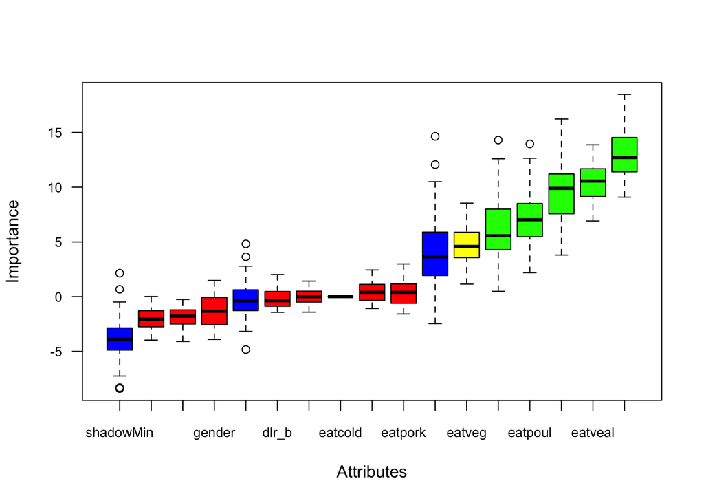

```r
plot(out.boruta, cex.axis = 0.8, las=1)
```

# Varrank

- load the R package varrank Using ?varrank perform variables selection on salmonella dataset. Interpret the output.

```r
library(varrank)
out.varrank <- varrank(data.df = salm.cc[,-c(1,2)], method = "estevez", variable.important = "casecontrol", discretization.method = "sturges", algorithm = "forward", scheme="mid", verbose = FALSE)

summary(out.varrank)
```

```
## Number of variables ranked: 14
## forward search using estevez method
## (mid scheme)
##
## Ordered variables (decreasing importance):
##        slt_a eatveal eatveg eatfruit eatpork eatlamb eatcold eatbeef dlr_a
## Scores 0.125   0.053  0.024    0.054    0.01       0   0.002  -0.011 0.002
##        eateggs gender  dlr_b eatpoul age
## Scores  -0.011 -0.015 -0.021   -0.02  NA
##
##  ---
##
##  Matrix of scores:
##          slt_a eatveal eatveg eatfruit eatpork eatlamb eatcold eatbeef
## slt_a    0.125
## eatveal  0.073   0.053
## eatveg    0.03   0.025  0.024
## eatfruit 0.067   0.036  0.006    0.054
## eatpork   0.04   0.022  0.018    0.017    0.01
## eatlamb  0.011  -0.078 -0.012   -0.006  -0.004       0
## eatcold  0.028   0.015 -0.009   -0.098  -0.122  -0.035   0.002
## eatbeef  0.008  -0.046 -0.019   -0.016  -0.013  -0.009   -0.01  -0.011
## dlr_a    0.054  -0.241 -0.158   -0.197  -0.603  -0.008  -0.218  -0.065
## eateggs  0.002       0 -0.006   -0.105  -0.008  -0.078  -0.034  -0.019
## gender   0.002       0 -0.012   -0.012  -0.011  -0.021  -0.017  -0.017
## dlr_b    0.006  -0.057 -0.038   -0.042  -0.062  -0.227  -0.017  -0.093
## eatpoul      0  -0.366 -0.098   -0.069  -0.112   -0.06  -0.039  -0.035
## age      0.005  -0.055 -0.029   -0.034  -0.025  -0.022  -0.019  -0.017
##           dlr_a eateggs gender  dlr_b eatpoul age
## slt_a
## eatveal
## eatveg
## eatfruit
## eatpork
## eatlamb
## eatcold
## eatbeef
## dlr_a     0.002
## eateggs  -0.012  -0.011
## gender   -0.015  -0.013 -0.015
## dlr_b    -0.053  -0.024 -0.018 -0.021
## eatpoul  -0.037  -0.033  -0.03 -0.022   -0.02
## age      -0.022  -0.027 -0.025 -0.032   -0.03
```

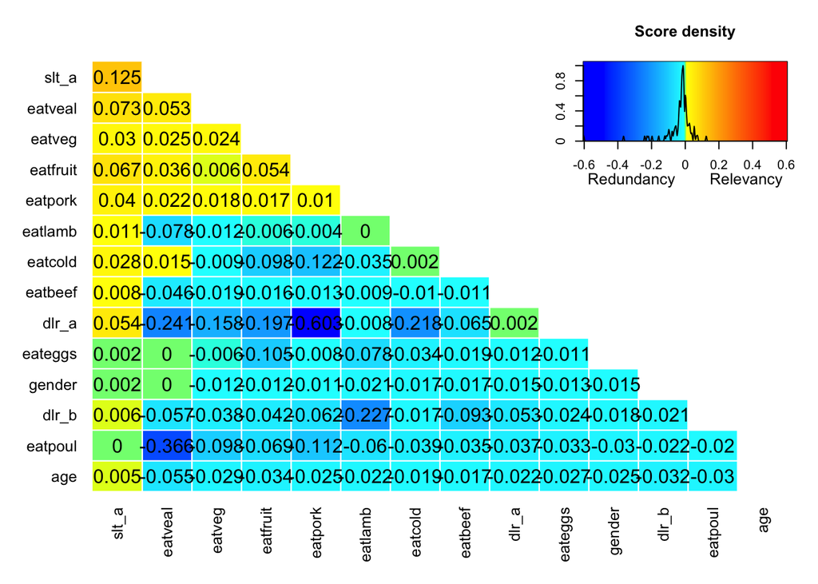

```r
plot(out.varrank)
```